# 共享单车用户满意度分析

Mr.Li

2/14/2020

### 1.获取随机调研的用户数据以及打分情况数据

```r
#更改工作目录
setwd('C:\\Users\\li\\Desktop\\r workfile')
getwd()
```

```
## [1] "C:/Users/li/Desktop/r workfile"
```

```r
#读取数据
custo.survey.data <- read.csv("customer survey data.csv")
survey.score.data <- read.csv("survey score data.csv")
#查看数据信息
View(custo.survey.data)
View(survey.score.data)
#查看数据结构
str(custo.survey.data)
```

```
## 'data.frame':    100 obs. of  7 variables:
##  $ ID      : int  1 2 3 4 5 6 7 8 9 10 ...
##  $ 城区    : Factor w/ 4 levels "朝阳区","东城区",..: 4 3 2 1 4 3 2 1 4 3 ...
##  $ 组别    : Factor w/ 2 levels "对照组","实验组": 1 1 1 1 1 1 1 1 1 1 ...
##  $ 年龄    : int  25 21 20 37 19 28 34 34 23 33 ...
##  $ 采访时间: Factor w/ 98 levels "2019/2/1 10:17",..: 11 21 44 82 3 81 85 52 47 91 ...
##  $ 车龄    : int  15 11 10 26 9 17 23 24 13 24 ...
##  $ 月收入  : int  4688 6564 3776 4688 6642 3776 4266 3758 4888 12160 ...
```

```r
str(survey.score.data)
```

```
## 'data.frame':    100 obs. of  2 variables:
##  $ ID  : int  1 2 3 4 5 6 7 8 9 10 ...
##  $ 分数: int  6 3 1 9 1 8 8 8 3 NA ...
```

```r
#查看数据大概情况
summary(custo.survey.data)
```

```
##        ID             城区        组别         年龄                 采访时间
##  Min.   :  1.00   朝阳区:25   对照组:50   Min.   :17.00   2019/2/1 14:12: 2
##  1st Qu.: 25.75   东城区:25   实验组:50   1st Qu.:22.75   2019/2/1 18:06: 2
##  Median : 50.50   海淀区:25               Median :27.00   2019/2/1 10:17: 1
##  Mean   : 50.50   西城区:25               Mean   :27.37   2019/2/1 10:25: 1
##  3rd Qu.: 75.25                           3rd Qu.:33.00   2019/2/1 10:37: 1
##  Max.   :100.00                           Max.   :40.00   2019/2/1 10:38: 1
##                                                           (Other)       :92
##       车龄           月收入
##  Min.   : 7.00   Min.   :  571
##  1st Qu.:13.00   1st Qu.: 4859
##  Median :17.00   Median : 5906
##  Mean   :17.33   Mean   : 8232
##  3rd Qu.:23.00   3rd Qu.:12060
##  Max.   :31.00   Max.   :24606
##
```

```r
summary(survey.score.data)
```

```
##        ID              分数
##  Min.   :  1.00   Min.   : 0.000
##  1st Qu.: 25.75   1st Qu.: 3.000
##  Median : 50.50   Median : 6.500
##  Mean   : 50.50   Mean   : 5.449
##  3rd Qu.: 75.25   3rd Qu.: 8.000
##  Max.   :100.00   Max.   :10.000
##                   NA's   :2
```

### 2.对获得的数据进行清洗去除缺失值和异常值等

```r
#数据清洗观察数据
summary(custo.survey.data)
```

```
##        ID             城区        组别         年龄                 采访时间
##  Min.   :  1.00   朝阳区:25   对照组:50   Min.   :17.00   2019/2/1 14:12: 2
##  1st Qu.: 25.75   东城区:25   实验组:50   1st Qu.:22.75   2019/2/1 18:06: 2
##  Median : 50.50   海淀区:25               Median :27.00   2019/2/1 10:17: 1
##  Mean   : 50.50   西城区:25               Mean   :27.37   2019/2/1 10:25: 1
##  3rd Qu.: 75.25                           3rd Qu.:33.00   2019/2/1 10:37: 1
##  Max.   :100.00                           Max.   :40.00   2019/2/1 10:38: 1
##                                                           (Other)       :92
##       车龄           月收入
##  Min.   : 7.00   Min.   :  571
##  1st Qu.:13.00   1st Qu.: 4859
##  Median :17.00   Median : 5906
##  Mean   :17.33   Mean   : 8232
##  3rd Qu.:23.00   3rd Qu.:12060
##  Max.   :31.00   Max.   :24606
##
```

```r
#以上得出顾客基本信息表无缺失值，异常值等情况
summary(survey.score.data)
```

```
##        ID              分数
##  Min.   :  1.00   Min.   : 0.000
##  1st Qu.: 25.75   1st Qu.: 3.000
##  Median : 50.50   Median : 6.500
##  Mean   : 50.50   Mean   : 5.449
##  3rd Qu.: 75.25   3rd Qu.: 8.000
##  Max.   :100.00   Max.   :10.000
##                   NA's   :2
```

```r
#得出分数列有两个缺失值
str(custo.survey.data)
```

```
## 'data.frame':    100 obs. of  7 variables:
##  $ ID      : int  1 2 3 4 5 6 7 8 9 10 ...
##  $ 城区    : Factor w/ 4 levels "朝阳区","东城区",..: 4 3 2 1 4 3 2 1 4 3 ...
##  $ 组别    : Factor w/ 2 levels "对照组","实验组": 1 1 1 1 1 1 1 1 1 1 ...
##  $ 年龄    : int  25 21 20 37 19 28 34 34 23 33 ...
##  $ 采访时间: Factor w/ 98 levels "2019/2/1 10:17",..: 11 21 44 82 3 81 85 52 47 91 ...
##  $ 车龄    : int  15 11 10 26 9 17 23 24 13 24 ...
##  $ 月收入  : int  4688 6564 3776 4688 6642 3776 4266 3758 4888 12160 ...
```

```r
custo.survey.data$采访时间 <- as.POSIXct(custo.survey.data$采访时间) #将采访时间转化为时间数据结构形式便于后续操作

survey.score.data[is.na(survey.score.data$分数),"分数"] <- mean(survey.score.data$分数,na.rm = TRUE) #用分数列的平均值补上缺失值
# head(survey.score.data)
```

### 3.数据转换，对两个表格进行合并，添加必要的列

```r
library(dplyr)#导入数据处理包
new.cus.data <- custo.survey.data %>%
  left_join(survey.score.data,by = "ID") %>%#合并表格
  mutate(采访时间=strftime(custo.survey.data$采访时间,"%H")) %>%
  mutate(分数排名 = as.numeric(rank(分数,ties.method = "min")))                    #因为采访时间是同一天，所以提取小时数，忽略几分几秒的影响
# new.cus.data
str(new.cus.data)#查看更改的类型为数字类型
```

```
## 'data.frame':    100 obs. of  9 variables:
##  $ ID      : int  1 2 3 4 5 6 7 8 9 10 ...
##  $ 城区    : Factor w/ 4 levels "朝阳区","东城区",..: 4 3 2 1 4 3 2 1 4 3 ...
##  $ 组别    : Factor w/ 2 levels "对照组","实验组": 1 1 1 1 1 1 1 1 1 1 ...
##  $ 年龄    : int  25 21 20 37 19 28 34 34 23 33 ...
##  $ 采访时间: chr  "11" "12" "15" "19" ...
##  $ 车龄    : int  15 11 10 26 9 17 23 24 13 24 ...
##  $ 月收入  : int  4688 6564 3776 4688 6642 3776 4266 3758 4888 12160 ...
##  $ 分数    : num  6 3 1 9 1 ...
##  $ 分数排名: num  48 21 2 88 2 65 65 65 21 46 ...
```

### 4.得到分析数据，进行数据探索判断不同数据分布规律以及数据间的关系，对数据进行探索

### 针对数据提出问题

- 年龄的分布情况
- 分数的分布情况
- 对照组和实验组的分数差异
- 不同城区的分数分布差异
- 采访时间与分数的关系
- 月收入与分数的关系
- 年龄与分数的关系
- 不同城区各年龄段所打分数的差异

#### 4.1年龄的分布情况

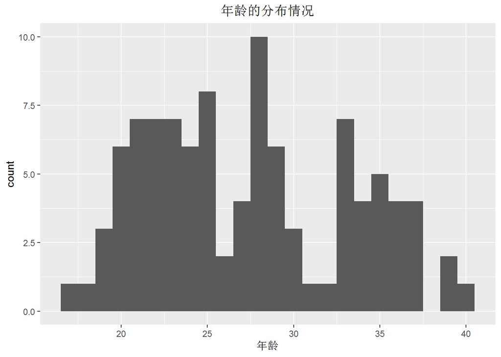

```r
#查看年龄的分布情况使用直方图以及基本统计
library(ggplot2)
ggplot(data = new.cus.data,aes(年龄)) + geom_histogram(binwidth = 1) + labs(title = '年龄的分布情况') + theme(plot.title = element_text(hjust = 0.5))
```

```r
mean(new.cus.data$年龄)
```

```
## [1] 27.37
```

```r
sd(new.cus.data$年龄)
```

```
## [1] 5.800827
```

```r
quantile(new.cus.data$年龄)
```

```
##    0%   25%   50%   75%  100%
## 17.00 22.75 27.00 33.00 40.00
```

#### 4.2分数的分布情况

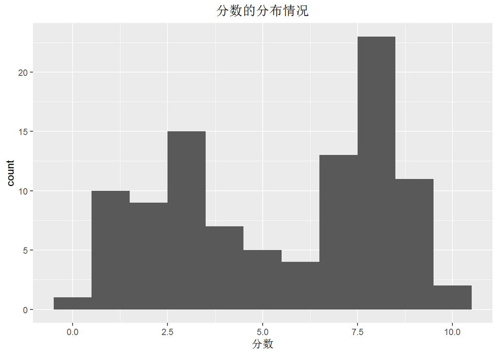

```r
#查看分数的分布情况使用直方图以及基本统计
ggplot(data = new.cus.data,aes(分数)) + geom_histogram(binwidth = 1) +labs(title = "分数的分布情况")+theme(plot.title = element_text(hjust = 0.5))
```

```r
mean(new.cus.data$分数)
```

```
## [1] 5.44898
```

```r
sd(new.cus.data$分数)
```

```
## [1] 2.846662
```

```r
quantile(new.cus.data$分数)
```

```
##   0%  25%  50%  75% 100%
##    0    3    6    8   10
```

得出基本结论：此次调查打分，平均分为5.45，标准差为2.85，其中分数分布在2.5到5.0之间以及7.5到10之间的分布最多